# Case - Processo Seletivo | Programa de Estágio 2023

## Por Araldo Rodrigues

### Importar os dados no notebook:

|  | Cargo | Diretoria | Departamento |
| --- | --- | --- | --- |
| 0 | CEO | Geral | NaN |
| 1 | Diretor | Produtos | NaN |
| 2 | Diretor | Engenharia | NaN |
| 3 | Diretor | Relacionamento com Clientes | NaN |
| 4 | Diretor | Administrativo | NaN |
| 5 | Diretor | Pessoas | NaN |
| 6 | Gerente | Produtos | Produtos horizontais |
| 7 | Gerente | Produtos | Produtos horizontais |
| 8 | Gerente | Produtos | Produtos verticais |
| 9 | Gerente | Produtos | Áreas comuns |

Foi dada a informação que alguns sistemas podem não estar funcionando adequadamente, por isso, podemos ter uma ideia da distribuição do número de funcionários por diretoria:

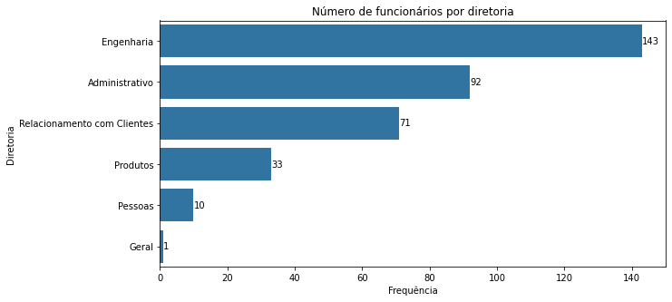

Como são cinco diretorias e existem 5 pessoas capacitadas para automação e dados, a primeira estratégia seria deixar uma pessoa responsável para estudar e entender as demandas de cada diretoria, e futuramente contratar mais pessoas para a área.

Além disso, podemos perceber que a diretoria de Pessoas possui bem menos funcionários que as outras. Uma primeira medida que poderia ser tomada seria realocar de outras diretorias (talvez Relacionamento com Clientes), como uma medida imediata, e ao longo prazo, aumentar o número de pessoas para a diretoria, contratando mais.

Podemos ver também a distribuição dos funcionários por departamento:

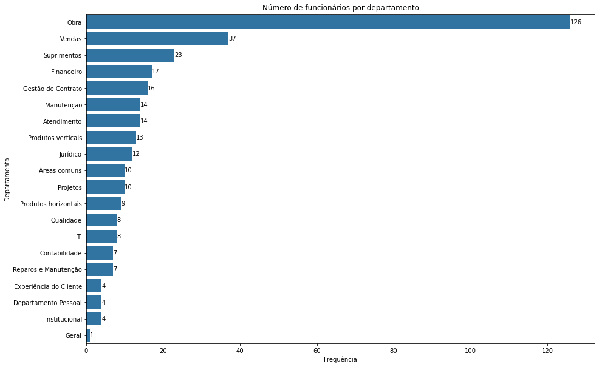

Outra informação dada é a de que a empresa pode investir 2 milhões em novos projetos. Com a distribuição dos funcionários por departamento, percebe-se que devem haver contratações na área de Projetos, podendo até dobrar o número de funcionários.

Com o aumento de projetos e funcionários do departamento, será necessário mais funcionários na área de vendas, por consequência.

Como última estratégia, para as contratações, devem-se levar em conta fortemente o departamento de Pessoas e os responsáveis por automação e dados, analisando as metas e vendo a necessidade de mais contratações.

Para isso, foi criado um plano de crescimento, visto na tabela abaixo:

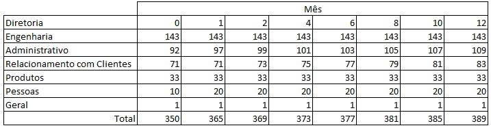

Por fim, as estrategias podem ser resumidas abaixo:

- Alocar cada funcionário responsável pela automação e dados para uma diretoria, e se possível contratar mais um para cada área para auxiliar;
- Aumentar a diretoria de Pessoas, com contratações imediatas;
- Contratar funcionários para o departamento de Projetos;
- Contratar funcionários para o departamento de Vendas;
- Alinhamento das áreas de dados e Pessoas, e montar o cronograma de cresimento de pessoas